# WFDB: An Introduction to the Waveform Database Software Package

```r
library(EGM)
```

Historically `{EGM}` wrapped the [Waveform Database (WFDB) software package](https://physionet.org/content/wfdb/10.7.0/), a well documented suite of `C` and `C++` applications for interacting with signal data. Recent releases of `{EGM}` now provide native readers, writers, and annotation utilities implemented directly in `R` and `C++`, so the core functionality of the package no longer depends on an external WFDB installation. You can work with WFDB headers, signals, and annotations on any system where `{EGM}` is installed, including CRAN environments.

Because `{EGM}` ships its own WFDB readers and writers, no additional system dependencies are required to begin analysing WFDB data in `R`. Installing `{EGM}` from CRAN (or the development version from GitHub) is sufficient for the examples in this guide to run end-to-end on any platform.

If you would still like to interface with the traditional `C`-based WFDB tools—for example to compare results or to call PhysioNet utilities that have not yet been ported—you can follow the instructions in the [WFDB GitHub repository](https://github.com/bemoody/wfdb). The `C`-based WFDB is more robust and has a full set of tools and functionality not found in the `R` version, however the key features of reading and writing data and annotators is compatible with the `R` implementation used by `{EGM}`.

# Signal Data

### Understanding the WFDB Storage Format

WFDB files store signal data as **integer values** (called **digital** units) in binary `.dat` files. These integers represent the raw output from an analog-to-digital converter (ADC). To convert these integer values to meaningful **physical** units (like millivolts), the WFDB header file (`.hea`) contains conversion metadata:

- **`gain`**: ADC units per physical unit (e.g., 200 ADC units per mV)
- **`baseline`**: The ADC value corresponding to 0 physical units
- **`units`**: The physical unit name (e.g., “mV”)

The conversion formula between digital and physical units is:

$$\text{physical} = \frac{\text{digital} - \text{baseline}}{\text{gain}}$$

And the inverse formula for writing:

$$\text{digital} = (\text{physical} \times \text{gain}) + \text{baseline}$$

### Reading Data in Different Units

The `read_wfdb()` and `read_signal()` functions support a `units` parameter that controls how signal data is returned:

- `units = "digital"` (default): Returns raw ADC counts as stored in the file
- `units = "physical"`: Returns values converted to physical units (e.g., mV)

Let’s demonstrate this concept using a WFDB file:

```r
# Locate the WFDB files in the package
dir_path <- system.file('extdata', package = 'EGM')

# Read the same data in both digital and physical units
ecg_digital <- read_wfdb(
  record = "muse-sinus",
  record_dir = dir_path,
  units = "digital"
)

ecg_physical <- read_wfdb(
  record = "muse-sinus",
  record_dir = dir_path,
  units = "physical"
)

# Examine the header to see the conversion parameters
head(ecg_digital$header)
```

```
#> <header_table: 12 channels, 5000 samples @ 500 Hz> muse-sinus
#>         file_name storage_format number ADC_gain ADC_baseline ADC_units
#>            <char>          <int>  <int>    <num>        <int>    <char>
#> 1: muse-sinus.dat             16      1      200            0        mV
#> 2: muse-sinus.dat             16      2      200            0        mV
#> 3: muse-sinus.dat             16      3      200            0        mV
#> 4: muse-sinus.dat             16      4      200            0        mV
#> 5: muse-sinus.dat             16      5      200            0        mV
#> 6: muse-sinus.dat             16      6      200            0        mV
#>    ADC_zero ADC_resolution initial_value checksum blocksize  label   lead
#>       <int>          <int>         <int>    <int>     <int> <fctr> <char>
#> 1:        0             16           -10    -3015         0      I      I
#> 2:        0             16             5    -6357         0     II     II
#> 3:        0             16            15    -3468         0    III    III
#> 4:        0             16            10    -4851         0    AVF    AVF
```

[output cut: 17 more lines]

Notice the `ADC_gain` and `ADC_baseline` columns in the header. In this example, all channels have a gain of 200 ADC units/mV and a baseline of 0. However, many real-world recordings have non-zero baseline values to account for DC offsets in the recording equipment.

## Comparing Digital and Physical Values

Let’s compare the first few samples from lead II in both formats:

```r
# Extract the first 10 samples from lead II
digital_values <- ecg_digital$signal$II[1:10]
physical_values <- ecg_physical$signal$II[1:10]

# Get the conversion parameters for lead II from the header
lead_ii_row <- ecg_digital$header[ecg_digital$header$label == "II", ]
gain <- lead_ii_row$ADC_gain
baseline <- lead_ii_row$ADC_baseline

# Create a comparison table
comparison <- data.frame(
  sample = 1:10,
  digital = digital_values,
  physical = round(physical_values, 3),
  calculated_physical = round((digital_values - baseline) / gain, 3)
)

print(comparison)
```

[output not shown]

```r
# Verify the conversion formula
cat("\nLead II conversion parameters:\n")
```

```
#>
#> Lead II conversion parameters:
```

```r
cat("  Gain:", gain, "ADC units/mV\n")
```

```
#>   Gain: 200 ADC units/mV
```

```r
cat("  Baseline:", baseline, "ADC units\n")
```

[output not shown]

The calculated physical units are derived from the digital units using the ADC conversion, and thus maintains the fidelity of the original signal.

# Annotations

The WFDB software package utilizes a binary format to store annotations. Annotations are essentially markers or qualifiers of specific components of a signal, specifying both the specific time or position in the plot, and what channel the annotation refers to. Annotations are polymorphic, and multiple can be applied to a single signal dataset. The credit for this work goes directly to the original software creators, as this is just a wrapper to allow for flexible integration into `R`. All of the demonstrations below rely on the native `{EGM}` parsers, so they run identically whether or not external WFDB binaries are present.

To begin, let’s take an example of a simple ECG dataset. This data is included in the package, and can be accessed as below.

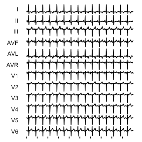

```r
fp <- system.file('extdata', 'muse-sinus.xml', package = 'EGM')
ecg <- read_muse(fp)
fig <- ggm(ecg) + theme_egm_light()
fig
```

We may have customized software, manual approaches, or machine learning models that may label signal data. We can use the `annotation_table()` function to create `WFDB`-compatible annotations, updating both the `egm` object and the written file. To trial this, let’s label the peaks of the QRS complex from this 12-lead ECG.

1. Create a quick, non-robust function for labeling QRS complex peaks. The function `pracma::findpeaks()` is quite good, but to avoid dependencies we are writing our own.
2. Evaluate the fit of the peaks to the dataset
3. Place the annotations into a table, updating the `egm` object
4. Plot the results

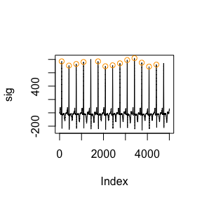

```r
# Let x = 10-second signal dataset
# We will apply this across the dataset
# This is an oversimplified approach.
find_peaks <- function(x,
                       threshold =
                         mean(x, na.rm = TRUE) + 2 * sd(x, na.rm = TRUE)
                       ) {

  # Ensure signal is "positive" for peak finding algorithm
  x <- abs(x)

  # Find the peaks
  peaks <- which(diff(sign(diff(x))) == -2) + 1

  # Filter the peaks
  peaks <- peaks[x[peaks] > threshold]

  # Return
  peaks
}

# Create a signal dataset
dat <- extract_signal(ecg)

# Find the peaks
sig <- dat[["I"]]
pk_loc <- find_peaks(sig)
pk_val <- sig[pk_loc]
pks <- data.frame(x = pk_loc, y = pk_val)

# Plot them
plot(sig, type = "l")
points(x = pks$x, y = pks$y, col = "orange")
```

The result is *not bad* for a simple peak finder, but it lets us generate a small dataset of annotations that can then be used. Please see the additional vignettes for advanced annotation options, such as multichannel plots, and multichannel annotations. We can take a look under the hood at the annotation positions we generated. The relevant arguments, which are displayed below, include:

- annotator: name of annotation function or creator
- time: constructed from sample number and frequency
- sample: integer index of positions
- type: a single character describing the type
- subtype: a single character describing the type
- channel: which channel the data is mapped to
- number: an additional qualifier of the annotation type

```r
# Find the peaks
raw_signal <- dat[["I"]]
peak_positions <- find_peaks(raw_signal)
peak_positions
```

```
#>  [1]   96  427  759 1091 1753 2085 2417 2750 3080 3412 3744 4076 4409
```

```r
# Annotations do not need to store the value at that time point however
# The annotation table function has the following arguments
args(annotation_table)
```

```
#> function (annotator = character(), time = character(), sample = integer(),
#>     frequency = integer(), type = character(), subtype = character(),
#>     channel = integer(), number = integer(), ...)
#> NULL
```

```r
# We can fill this in as below using additional data from the original ECG
hea <- ecg$header
start <- attributes(hea)$record_line$start_time
hz <- attributes(hea)$record_line$frequency

ann <- annotation_table(
  annotator = "our_pks",
  sample = peak_positions,
  type = "R",
  frequency = hz,
  channel = "I"
)

# Here are our annotations
ann
```

```
#> <annotation_table: 13 `our_pks` annotations>
#>             time sample   type subtype channel number
#>           <char>  <num> <char>  <char>  <char>  <int>
#>  1: 00:00:00.192     96      R               I      0
#>  2: 00:00:00.854    427      R               I      0
#>  3: 00:00:01.518    759      R               I      0
#>  4: 00:00:02.182   1091      R               I      0
#>  5: 00:00:03.506   1753      R               I      0
#>  6:  00:00:04.17   2085      R               I      0
#>  7: 00:00:04.834   2417      R               I      0
#>  8:   00:00:05.5   2750      R               I      0
#>  9:  00:00:06.16   3080      R               I      0
#> 10: 00:00:06.824   3412      R               I      0
#> 11: 00:00:07.488   3744      R               I      0
#> 12: 00:00:08.152   4076      R               I      0
#> 13: 00:00:08.818   4409      R               I      0
```

```r
# Then, add this back to the original signal
ecg$annotation <- ann
ecg
```

```
#> <Electrogram>
#> -------------------
#> Recording Duration:  10 seconds
#> Recording frequency  500  hz
#> Number of channels:  12
#> Channel Names:  I II III AVF AVL AVR V1 V2 V3 V4 V5 V6
#> Annotation:  our_pks
#> Type: Standard 12-lead ECG
```